# 2. Wizualizacja

Region zamieszkania ma wpływ na decyzję o zakupie roweru. Może to wynikać z różnic w infrastrukturze rowerowej, klimacie lub kulturze aktywnego spędzania czasu w poszczególnych regionach.

**Wykres 5. Status Związkowy a zakup roweru**

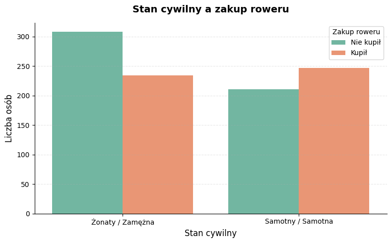

Widzimy na wykresie, że w przypadku osób w małżeństwie więcej osób nie zakupiło roweru, niż kupiło. W przypadku singli proporcje się odwracają.

**Wykres 6. Wielowymiarowa analiza**

Tutaj użyjemy funkcji pairplot, aby zrobic macierz wykresów.

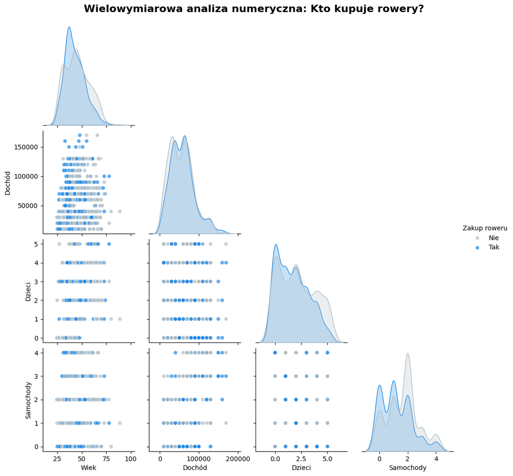

**1. Profil demograficzny (Wiek i Dochód)** Analiza rozkładów brzegowych wskazuje, że decyzję o zakupie roweru najczęściej podejmują osoby w wieku średnim (ok. 35-50 lat) dysponujące dochodem na poziomie średnim i wyższym. Na wykresie punktowym relacji wieku do dochodu nie obserwuje się wyraźnego trendu liniowego, co świadczy o braku silnej współliniowości.

**Wykres 7. Heatmapa**

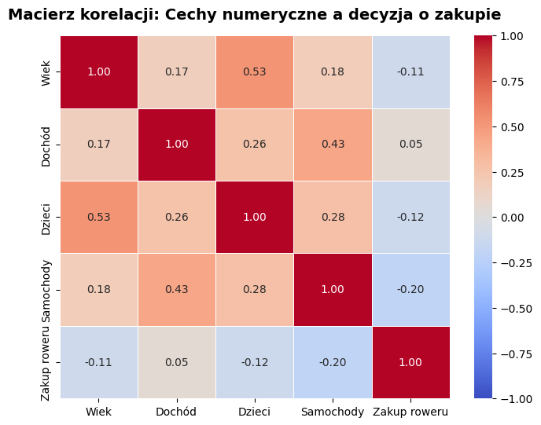

Ogólna siła korelacji liniowych w badanym zbiorze danych jest niska. Nie obserwujemy żadnych silnych zależności między analizowanymi zmiennymi, a już napewno między zakupem roweru a pozostałymi zmiennymi.

Oznacza to brak wyraźnego, bezpośredniego i proporcjonalnego (liniowego) wpływu pojedynczych cech numerycznych na decyzję o zakupie roweru. Wszystkie widoczne na mapie słabsze powiązania należy w tym ujęciu traktować jako mało znaczące.

Widzimy umiarkowaną dodatnią korelację między Dochodem, a liczbą posiadanych aut (co ma sens logiczny) na poziomie 0.43, a także korelację 0.53 między liczbą posiadanych dzieci a wiekiem (co też trudno odnieść do samego zakupu roweru.)